# Naufal_Rasyid_S_DataBank

- Kesimpulan

Maka kumpulan data menunjukkan korelasi yang lemah di antara variabel-variabel, yang mengindikasikan bahwa hubungan linear di antara sebagian besar pasangan variabel tidak kuat.

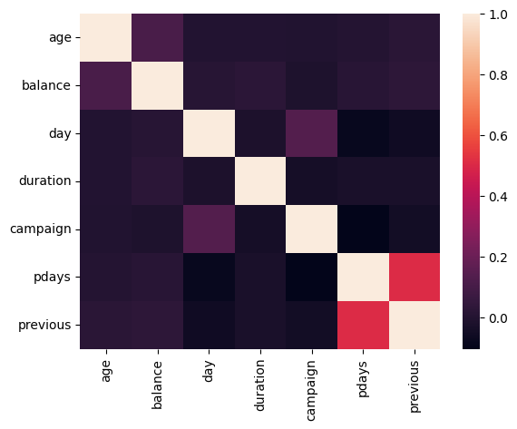

```python
cor= df.corr()
sns.heatmap(cor)
```

Lalu kita melakukan check outlier pada dataset

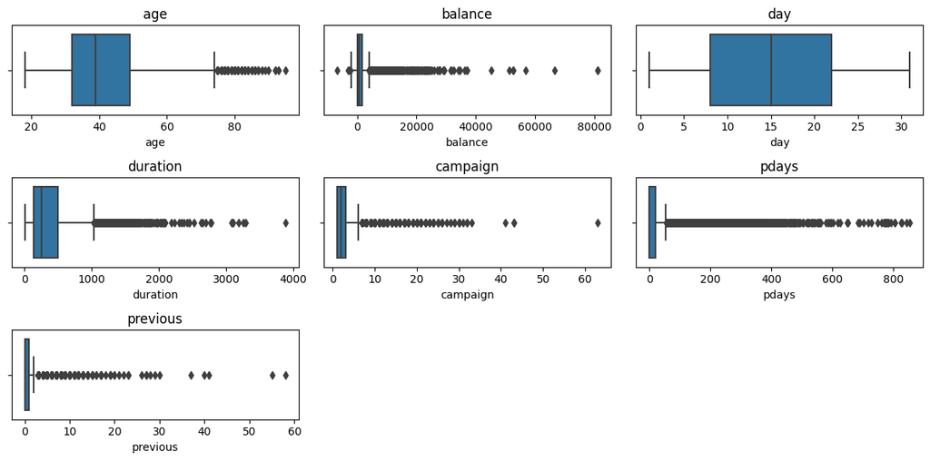

```python
# #Check Outliers
num_cols = df.select_dtypes(include=["number"])
plt.figure(figsize=(12, 6))
for i, col in enumerate(num_cols.columns):
    plt.subplot(3, 3, i + 1)  # Index starts from 1 in subplot
    sns.boxplot(x=num_cols[col])
    plt.title(col)

# Adjust layout to prevent overlapping titles
plt.tight_layout()
plt.show()
```

Dalam latihan ini, saya karena data set nya merupakan bank maka saya berkesimpulan balance dan age sudah pasti ada jarak antara data dari setiap customer, maka saya memilih :

- campaign > 40 outliers
- previous > 40 outliers
- duration > 3000 outliers

tetapi, saya masih dalam proses belajar menghandle dataset seperti ini dan masih perlu referensi dari spesialis yang dapat mengidentifikasi lebih baik daripada saya apakah nilai-nilai ekstrem tersebut merupakan outliers :)

Lalu kita handle outliers menggunakan filtering

- campaign > 40 outliers
- previous > 40 outliers
- duration > 3000 outliers

```python
df = df.loc[df['campaign'] < 40]

df = df.loc[df['previous'] < 40]

df = df.loc[df['duration'] < 3000]
```

check data set yang sudah di filtering

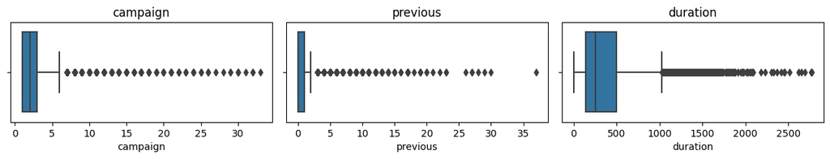

```python
check_outliers = df[['campaign', 'previous', 'duration']]

plt.figure(figsize=(12, 6))
for i, col in enumerate(check_outliers.columns):
    plt.subplot(3, 3, i + 1)  # Index starts from 1 in subplot
    sns.boxplot(x=check_outliers[col])
    plt.title(col)

# Adjust layout to prevent overlapping titles
plt.tight_layout()
plt.show()
```

hasilnya setelah di filtering sudah berbeda dari sebelumnya

**2. Data Visualisasi**

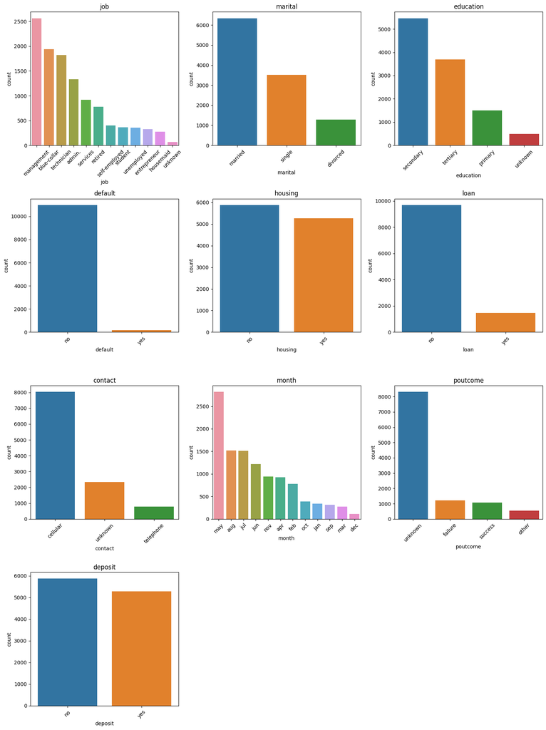

```python
char_cols = df.select_dtypes(include=["object"])
plt.figure(figsize=(25, 15))
num_rows = (len(char_cols.columns) + 2) // 3
num_cols_subplot = 3

plt.figure(figsize=(15, 5 * num_rows))
for i, col in enumerate(char_cols.columns):
  plt.subplot(num_rows, num_cols_subplot, i + 1)
  sns.countplot(x=char_cols[col],order=df[col].value_counts().index)
  plt.title(col)
  plt.xticks(rotation=45)

# Adjust layout to prevent overlapping titles
plt.tight_layout()
# plt.show(block=True)
plt.show()
```

Data Insight:

Overall Conclusion:

- The dataset provides a comprehensive view of client demographics, contact methods, and outcomes of previous campaigns.
- Certain features, such as age, job, education, and balance, can be further explored to understand their impact on the likelihood of a client making a term deposit.
- This information is valuable for targeted marketing strategies and improving campaign effectiveness.

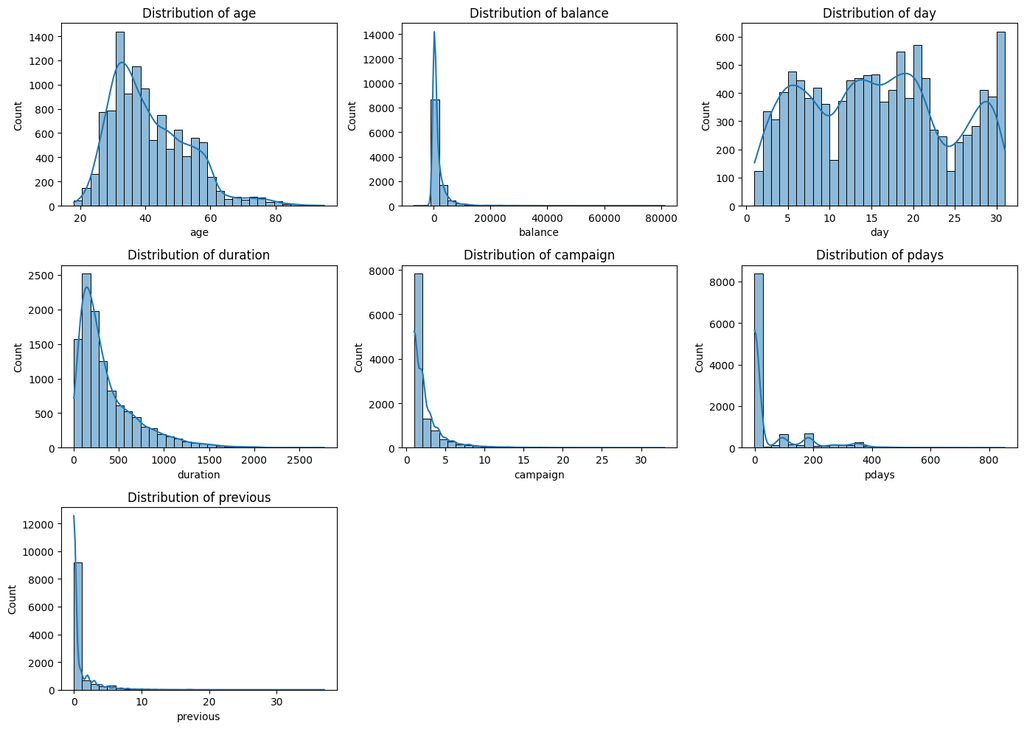

```python
# Set the style and size for the plots
num_cols = df.select_dtypes(include=["number"])
plt.figure(figsize=(14, 10))

# List of numerical features
# num_cols

# Plot the distribution of numerical features
for i, feature in enumerate(num_cols, 1):
    plt.subplot(3, 3, i)
    sns.histplot(df[feature], bins=30, kde=True)
    plt.title(f'Distribution of {feature}')

plt.tight_layout()
plt.show()
```

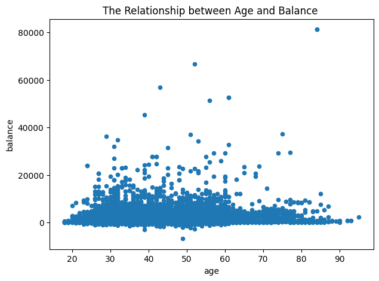

```python
scatter_age = df.plot.scatter('age','balance',figsize = (7,5))

plt.title('The Relationship between Age and Balance ')
plt.show()
```

Data Visualisasi Deposit

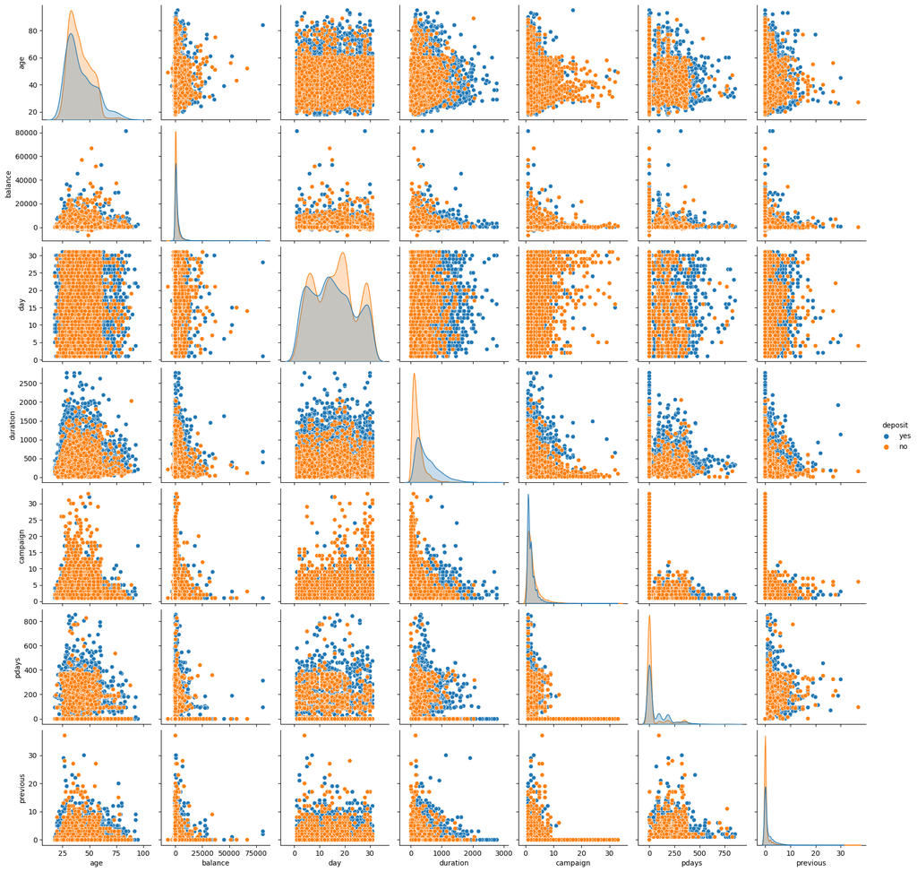

```python
sns.pairplot(df, hue='deposit')
```

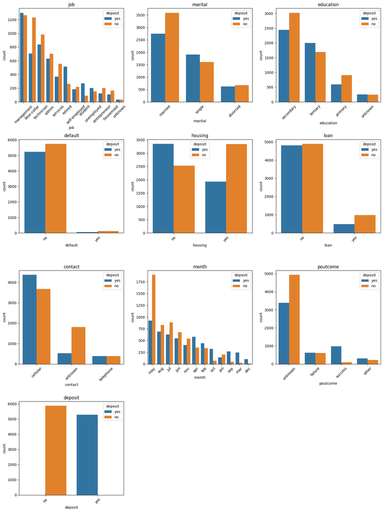

```python
char_cols = df.select_dtypes(include=["object"])
plt.figure(figsize=(25, 15))

num_rows = (len(char_cols.columns) + 2) // 3
num_cols_subplot = 3

plt.figure(figsize=(15, 5 * num_rows))

for i, col in enumerate(char_cols.columns):
    plt.subplot(num_rows, num_cols_subplot, i + 1)
    sns.countplot(x=col, hue='deposit', data=df, order=df[col].value_counts().index)
    plt.title(col)
    plt.xticks(rotation=45)

# Adjust layout to prevent overlapping titles
plt.tight_layout()
plt.show()
```

Data Insight :

```python
print('Deposit vs Marital :\n',pd.crosstab(df['deposit'], df['marital']))
print('\nDeposit vs contact :\n',pd.crosstab(df['deposit'], df['contact']))
print('\nDeposit vs poutcome :\n',pd.crosstab(df['deposit'], df['poutcome']))
print('\nDeposit vs Education :\n',pd.crosstab(df['deposit'], df['education']))
print('\nDeposit vs Month :\n',pd.crosstab(df['deposit'], df['month']))
print('\nDeposit vs Job :\n',pd.crosstab(df['deposit'], df['job']))
print('\nDeposit vs Default :\n',pd.crosstab(df['deposit'], df['default']))
print('\nDeposit vs Housing :\n',pd.crosstab(df['deposit'], df['housing']))
print('\nDeposit vs Loan :\n',pd.crosstab(df['deposit'], df['loan']))
```

```
Deposit vs Marital :
 marital  divorced  married  single
deposit
no            671     3590    1605
yes           621     2750    1910

Deposit vs contact :
 contact  cellular  telephone  unknown
deposit
no           3671        382     1813
yes          4365        389      527

Deposit vs poutcome :
 poutcome  failure  other  success  unknown
deposit
no            610    228       93     4935
yes           617    306      978     3380

Deposit vs Education :
 education  primary  secondary  tertiary  unknown
deposit
no             908       3022      1693      243
yes            590       2444      1995      252

Deposit vs Month :
 month    apr  aug  dec  feb  jan  jul  jun  mar   may  nov  oct  sep
deposit
no       346  831   10  335  201  885  676   28  1897  540   68   49
yes      577  688  100  440  142  626  544  247   923  403  322  269

Deposit vs Job :
 job      admin.  blue-collar  entrepreneur  housemaid  management  retired  \
deposit
no          702         1232           205        165        1264      262
yes         629          706           123        109        1300      516

job      self-employed  services  student  technician  unemployed  unknown
deposit
no                 218       554       91         982         155       36
yes                186       368      269         839         202       34

Deposit vs Default :
 default    no  yes
deposit
no       5750  116
yes      5229   52

Deposit vs Housing :
 housing    no   yes
deposit
no       2526  3340
yes      3352  1929

Deposit vs Loan :
 loan       no  yes
deposit
no       4892  974
yes      4802  479
```

Setelah melakukan analisis visualisasi kita melanjutkan untuk memprediksi, apakah customer akan melakukan deposit atau tidak?

**3. Modeling**

Modeling dilakukan dengan beberapa jenis pendekatan seperti clasiffier dan regresi

```python
df_model = df.copy()
```

```python
df_model.info()
```

```
<class 'pandas.core.frame.DataFrame'>
Int64Index: 11147 entries, 0 to 11161
Data columns (total 17 columns):
 #   Column     Non-Null Count  Dtype
---  ------     --------------  -----
 0   age        11147 non-null  int64
 1   job        11147 non-null  object
 2   marital    11147 non-null  object
 3   education  11147 non-null  object
 4   default    11147 non-null  object
 5   balance    11147 non-null  int64
 6   housing    11147 non-null  object
 7   loan       11147 non-null  object
 8   contact    11147 non-null  object
 9   day        11147 non-null  int64
 10  month      11147 non-null  object
 11  duration   11147 non-null  int64
 12  campaign   11147 non-null  int64
 13  pdays      11147 non-null  int64
 14  previous   11147 non-null  int64
 15  poutcome   11147 non-null  object
 16  deposit    11147 non-null  object
dtypes: int64(7), object(10)
memory usage: 1.5+ MB
```

```python
print(df_model.duplicated().sum())
```

```
0
```

```python
df_model.describe()
```

|  | age | balance | day | duration | campaign | pdays | previous |
| --- | --- | --- | --- | --- | --- | --- | --- |
| count | 11147.000000 | 11147.000000 | 11147.000000 | 11147.000000 | 11147.000000 | 11147.000000 | 11147.000000 |
| mean | 41.232439 | 1528.809814 | 15.656589 | 370.295236 | 2.492778 | 51.205167 | 0.816273 |
| std | 11.916551 | 3226.415010 | 8.421460 | 339.553921 | 2.581285 | 108.326443 | 2.102516 |
| min | 18.000000 | -6847.000000 | 1.000000 | 2.000000 | 1.000000 | -1.000000 | 0.000000 |
| 25% | 32.000000 | 122.500000 | 8.000000 | 138.000000 | 1.000000 | -1.000000 | 0.000000 |
| 50% | 39.000000 | 550.000000 | 15.000000 | 255.000000 | 2.000000 | -1.000000 | 0.000000 |
| 75% | 49.000000 | 1709.500000 | 22.000000 | 495.000000 | 3.000000 | 20.500000 | 1.000000 |
| max | 95.000000 | 81204.000000 | 31.000000 | 2775.000000 | 33.000000 | 854.000000 | 37.000000 |

```python
df_model.info()
```

```
<class 'pandas.core.frame.DataFrame'>
Int64Index: 11147 entries, 0 to 11161
Data columns (total 17 columns):
 #   Column     Non-Null Count  Dtype
---  ------     --------------  -----
 0   age        11147 non-null  int64
 1   job        11147 non-null  object
 2   marital    11147 non-null  object
 3   education  11147 non-null  object
 4   default    11147 non-null  object
 5   balance    11147 non-null  int64
 6   housing    11147 non-null  object
 7   loan       11147 non-null  object
 8   contact    11147 non-null  object
 9   day        11147 non-null  int64
 10  month      11147 non-null  object
 11  duration   11147 non-null  int64
 12  campaign   11147 non-null  int64
 13  pdays      11147 non-null  int64
 14  previous   11147 non-null  int64
 15  poutcome   11147 non-null  object
 16  deposit    11147 non-null  object
dtypes: int64(7), object(10)
memory usage: 1.5+ MB
```

Melakukan Feature engineering pada chategorical var

```python
char_feature = df_model.select_dtypes(include=["object"]).columns
#Check values pada semua column
for col in df_model[char_feature]:
  value = df_model[col].value_counts()
  print(f"Values count column '{col}': \n{value}\n")
```

```
Values count column 'job':
management       2564
blue-collar      1938
technician       1821
admin.           1331
services          922
retired           778
self-employed     404
student           360
unemployed        357
entrepreneur      328
housemaid         274
unknown            70
Name: job, dtype: int64

Values count column 'marital':
married     6340
single      3515
divorced    1292
Name: marital, dtype: int64

Values count column 'education':
secondary    5466
tertiary     3688
primary      1498
unknown       495
Name: education, dtype: int64

Values count column 'default':
no     10979
yes      168
Name: default, dtype: int64

Values count column 'housing':
no     5878
yes    5269
Name: housing, dtype: int64

Values count column 'loan':
no     9694
```

[output cut: 20 more lines]

```
mar     275
dec     110
Name: month, dtype: int64

Values count column 'poutcome':
unknown    8315
failure    1227
success    1071
other       534
Name: poutcome, dtype: int64

Values count column 'deposit':
no     5866
yes    5281
Name: deposit, dtype: int64
```

Melakukan Label Encoder untuk setiap chategorical data

```python
from sklearn.model_selection import train_test_split
from sklearn.preprocessing import LabelEncoder

label = LabelEncoder()
df_model[char_feature] = df_model[char_feature].apply(label.fit_transform)
```

```python
#Check kategorical data yang sudah di label encoder
for col in df_model[char_feature]:
  value = df_model[col].value_counts()
  print(f"Values count column '{col}': \n{value}\n")
```

```
Values count column 'job':
4     2564
1     1938
9     1821
0     1331
7      922
5      778
6      404
8      360
10     357
2      328
3      274
11      70
Name: job, dtype: int64

Values count column 'marital':
1    6340
2    3515
0    1292
Name: marital, dtype: int64

Values count column 'education':
1    5466
2    3688
0    1498
3     495
Name: education, dtype: int64

Values count column 'default':
0    10979
1      168
Name: default, dtype: int64

Values count column 'housing':
0    5878
1    5269
Name: housing, dtype: int64

Values count column 'loan':
0    9694
```

[output cut: 20 more lines]

```
7      275
2      110
Name: month, dtype: int64

Values count column 'poutcome':
3    8315
0    1227
2    1071
1     534
Name: poutcome, dtype: int64

Values count column 'deposit':
0    5866
1    5281
Name: deposit, dtype: int64
```

```python
df['deposit'].value_counts()
```

```
no     5866
yes    5281
Name: deposit, dtype: int64
```

```python
df_model['deposit'].value_counts()
```

```
0    5866
1    5281
Name: deposit, dtype: int64
```

disini 'no' = 0 dan 'yes' = 1, berlaku sesuai isi unique values pada setiap column

**Lalu feature engineering numerical variable**